# Time Series Study on CO2 Emissions and Hybrid Car Sales Project

Grace Lang & Jules Stacy

3/18/2021

# Business Objective:

Taking care of our environment now will help our health and the health of future generations. Air pollution from vehicle CO2 Emissions can cause respiratory diseases and cancer.

In addition to emitting less CO2, hybrid cars have had sales on the rise in recent years due to their fuel efficiency and environmental benefits.

Popularity of wind turbines have also increased over time as more landowners are willing to get them installed on their land for energy rights and economic benefit. Our mission is to identify and provide insights of macro trends within the environmental industry.

# Data sources:

- Hybrid Car sales: https://afdc.energy.gov/data/10301
- CO2 Emissions by Country: https://data.worldbank.org/indicator/EN.ATM.CO2E.PC?view=map
- Turbine data citation: https://doi.org/10.5066/F7TX3DN0

## Rolling Window ASE Function (ARIMA):

This function calculates the ASE along a rolling window that iterates over the data from start to finish.

```r
R_W_ASE = function(series, trainingSize, horizon=1, s=0, d=0, phis=0, thetas=0)
{
  trainingSize=trainingSize
  horizon=horizon
  ASEHolder=numeric()
  s=s
  d=d
  phis=phis
  thetas=thetas

for( i in 1:(length(series)-(trainingSize + horizon) + 1))
{
  forecasts = fore.aruma.wge(series[i:(i+(trainingSize-1))], phi=phis, theta=thetas, s=s, d=d, n.ahead=horizon, plot=FALSE)

  ASE=mean((series[(trainingSize+i):(trainingSize + i + (horizon) - 1)] - forecasts$f)^2)
  print(paste0('i: ', i))
  print(paste0('ASE: ', ASE))
  ASEHolder[i] = ASE
}
  ASEHolder
  hist(ASEHolder)
  WindowedASE = mean(ASEHolder)

  print("The Summary Statistics for the Rolling Window ASE Are:")
  print(summary(ASEHolder))
  print(paste("The Rolling Window ASE is: ", WindowedASE))
  return(WindowedASE)
}
```

#Rolling Window ASE function (VAR)

```r
R_W_ASE_VAR = function(series, trainingSize, horizon=1, model)
{
  trainingSize=trainingSize
  horizon=horizon
  model=model #have to pass in the VAR model
  ASEHolder=numeric()


for( i in 1:(length(series)-(trainingSize + horizon) + 1))
{

  #forecasts = fore.aruma.wge(series[i:(i+(trainingSize-1))], phi=phis, theta=thetas, s=s, d=d, n.ahead=horizon, plot=FALSE)

  #develop a forecast given the chosen VAR model
  forecasts = predict(model,n.ahead = horizon)

  ASE=mean((series[(trainingSize+i):(trainingSize + i + (horizon) - 1)] - forecasts$fcst$CO2[,1])^2)
  print(paste0('i: ', i))
  print(paste0('ASE: ', ASE))
  ASEHolder[i] = ASE
}
  ASEHolder
  hist(ASEHolder)
  WindowedASE = mean(ASEHolder)

  print("The Summary Statistics for the Rolling Window ASE Are:")
  print(summary(ASEHolder))
  print(paste("The Rolling Window ASE is: ", WindowedASE))
  return(WindowedASE)
}
```

# Rolling Window ASE Function (Ensemble)

```r
R_W_ASE_ENS = function(series, trainingSize, horizon=1, varmodel, s=0, d=0, phis=0, thetas=0)
{
  trainingSize=trainingSize
  horizon=horizon
  varmodel=varmodel #have to pass in the VAR model
  ASEHolder=numeric()


for( i in 1:(length(series)-(trainingSize + horizon) + 1))
{

  #forecasts = fore.aruma.wge(series[i:(i+(trainingSize-1))], phi=phis, theta=thetas, s=s, d=d, n.ahead=horizon, plot=FALSE)

  #develop a forecast given the chosen VAR model
  armafore = fore.aruma.wge(series[i:(i+(trainingSize-1))], phi=phis, theta=thetas, s=s, d=d, n.ahead=horizon, plot=FALSE)

  forecasts = predict(varmodel,n.ahead = horizon)
  forecasts = (forecasts$fcst$CO2[,1] + armafore$f)/2

  ASE=mean((series[(trainingSize+i):(trainingSize + i + (horizon) - 1)] - forecasts)^2)
  print(paste0('i: ', i))
  print(paste0('ASE: ', ASE))
  ASEHolder[i] = ASE
}
  ASEHolder
  hist(ASEHolder)
  WindowedASE = mean(ASEHolder)

  print("The Summary Statistics for the Rolling Window ASE Are:")
  print(summary(ASEHolder))
  print(paste("The Rolling Window ASE is: ", WindowedASE))
  return(WindowedASE)
}
```

#Static end-of-data ASE function

```r
#ASE's and Forecasts ================
#5 years out
#n.ahead=5
#series = alldata$CO2
StaticASE = function(series, forecast, n.ahead){
  series = series
  forecast = forecast
  n.ahead = n.ahead

ASE = mean((forecast - series[(length_all-n.ahead+1):length_all])^2)
#display ASE: 0.501437
print(paste0(n.ahead, " year ASE: ", ASE))
}
```

# Loading in data & cleanup:

```r
#Loading in the CO2 Emission data
car_orig <- read.csv("./HybridCar.csv")
#Remove years that are majority blank
car <- car_orig[40:60,] #This may not be used in the modeling

#Rename column to something easier
names(car)[names(car) == "CO2.emissions..metric.tons.per.capita."] <- "CO2"

#Loading in the wind turbine data
turbine <- read.csv("./turbines.csv")
turbine_tot = aggregate(turbine$p_tnum, by=list(Category=turbine$p_year), FUN=sum)
turbine_tot
```

```
##    Category      x
## 1      1981   7486
## 2      1982 570754
## 3      1983 198725
## 4      1984  19951
## 5      1985 125598
## 6      1986   9676
## 7      1987  52466
## 8      1988  40067
## 9      1989  85536
## 10     1990 111639
## 11     1991    327
## 12     1992    149
## 13     1994   1060
## 14     1995   1765
```

[output cut: 25 more lines]

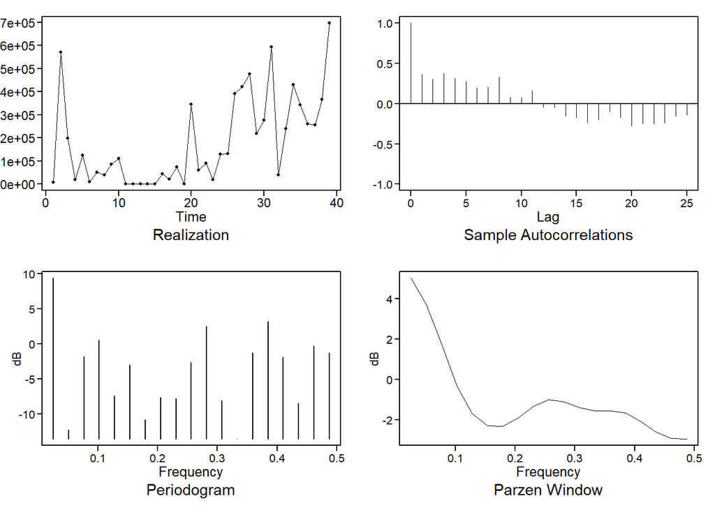

```
## $autplt
##  [1]  1.00000000  0.36025928  0.30025259  0.37485552  0.31778942  0.27440194
##  [7]  0.19500135  0.20709268  0.32720655  0.07835525  0.07115995  0.15544063
## [13] -0.04303713 -0.04861112 -0.15182562 -0.17333959 -0.23955326 -0.19849302
## [19] -0.09813862 -0.17366771 -0.27791737 -0.24232263 -0.25449897 -0.23754598
## [25] -0.15068379 -0.14242353
##
## $freq
##  [1] 0.02564103 0.05128205 0.07692308 0.10256410 0.12820513 0.15384615
##  [7] 0.17948718 0.20512821 0.23076923 0.25641026 0.28205128 0.30769231
## [13] 0.33333333 0.35897436 0.38461538 0.41025641 0.43589744 0.46153846
## [19] 0.48717949
##
## $db
##  [1]   9.3796177 -12.2292902  -1.7602255   0.5546536  -7.3807364  -3.0346178
##  [7] -10.7706796  -7.6596377  -7.7736053  -2.6119579   2.5181990  -8.0541442
## [13] -13.5535740  -1.2456046   3.2101171  -1.8640317  -8.4483142  -0.2628387
## [19]  -1.2395665
##
## $dbz
##  [1]  5.0217031  3.7043131  1.7476480 -0.2898749 -1.6910531 -2.2994156
##  [7] -2.3303531 -1.8955723 -1.3160597 -1.0112799 -1.1177078 -1.4165984
## [13] -1.5679807 -1.5519056 -1.6705745 -2.0904682 -2.6215595 -2.9260260
## [19] -2.9692760
```

```r
#Renaming wind turbine column
names(turbine_tot)[names(turbine_tot) == "x"] <- "wind"
plotts.sample.wge(turbine_tot$wind)
```

```r
# Data cleanup

#turbine data is missing 1993
x<- turbine_tot[1:35,]
x<- x %>% add_row(Category = 1993, wind = 0, .before = 13)
#shorten to just the years with cross-over data
y<- car_orig[22:57,1:3]
#combine the 2 datasets
alldata <- cbind(x,y)
#alldata <- select(alldata,-USA) #remove duplicate year column that was for reference
#Rename column to something easier
names(alldata)[names(alldata) == "CO2.emissions..metric.tons.per.capita."] <- "CO2"

# A selection of the data from the 3 datasets will be used for modeling.
  #All NA's will be replaced with 0
alldata[is.na(alldata)] = 0
length_all = length(alldata$CO2)

#building dataframes for later use
last5 = alldata[(length_all-4):length_all,]
minuslast5 = alldata[0:(length_all-5),]

last20 = alldata[(length_all-19):length_all,]
minuslast20 = alldata[0:(length_all-20),]
```

# Initial look at data plotted out

Data cut differently by years to see if we need to subset the data for a specific timeframe.

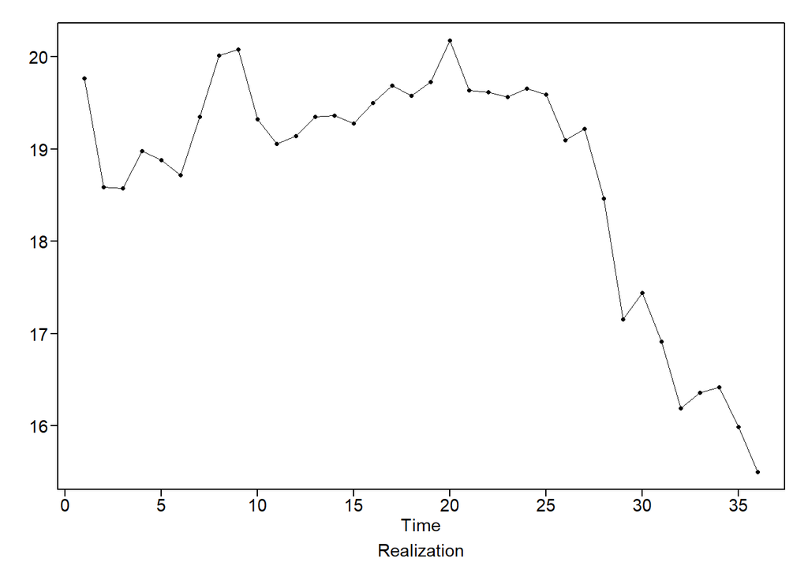

```r
plotts.wge(alldata$CO2)
```

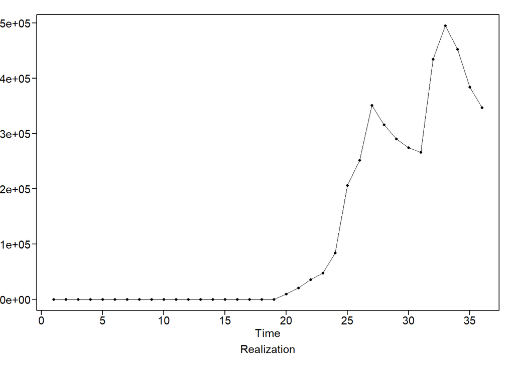

```r
plotts.wge(alldata$TotalSales)
```

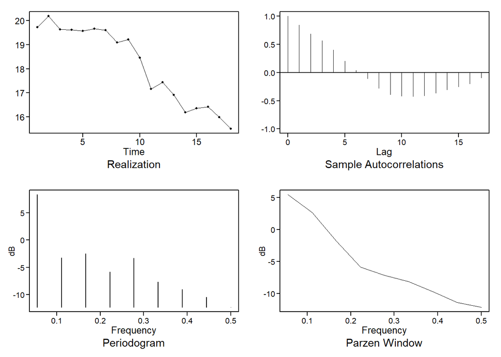

```
## $autplt
##  [1]  1.00000000  0.84278067  0.68619711  0.56965527  0.39893140  0.20148472
##  [7]  0.03847587 -0.10426037 -0.27718765 -0.38976123 -0.41794196 -0.42285946
## [13] -0.41123213 -0.36672598 -0.30394205 -0.25027610 -0.19878872 -0.09454938
##
## $freq
## [1] 0.05555556 0.11111111 0.16666667 0.22222222 0.27777778 0.33333333 0.38888889
## [8] 0.44444444 0.50000000
##
## $db
## [1]   8.343580  -3.247260  -2.488336  -5.862016  -3.349907  -7.680591  -9.080902
## [8] -10.515067 -12.362169
##
## $dbz
## [1]   5.447551   2.691892  -1.768814  -5.893361  -7.168790  -8.139466  -9.718991
## [8] -11.391070 -12.161125
```

```r
car_1 <- car_orig[40:57,]
plotts.sample.wge(car_1$CO2)
```

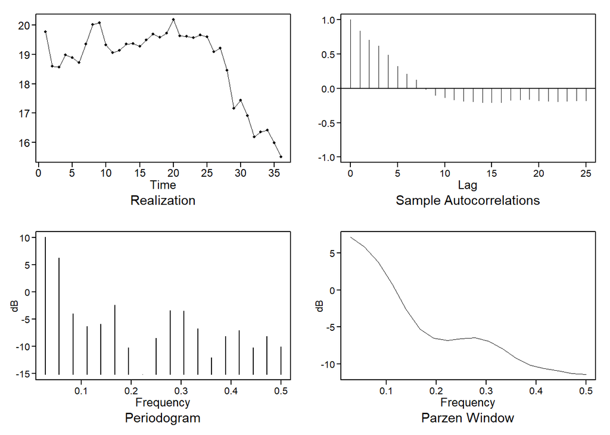

```
## $autplt
##  [1]  1.00000000  0.83880095  0.70631089  0.61828086  0.48624413  0.32441203
##  [7]  0.21013770  0.12202428 -0.01090714 -0.10204501 -0.13210805 -0.16824737
## [13] -0.18559263 -0.19393303 -0.20520626 -0.20569900 -0.20266985 -0.17415374
## [19] -0.16361462 -0.16183009 -0.17653322 -0.18337914 -0.19142185 -0.18622071
## [25] -0.18218041 -0.18130190
##
## $freq
##  [1] 0.02777778 0.05555556 0.08333333 0.11111111 0.13888889 0.16666667
##  [7] 0.19444444 0.22222222 0.25000000 0.27777778 0.30555556 0.33333333
## [13] 0.36111111 0.38888889 0.41666667 0.44444444 0.47222222 0.50000000
##
## $db
##  [1]  10.079212   6.266477  -3.950668  -6.258239  -5.870440  -2.343800
##  [7] -10.251454 -15.157110  -8.502239  -3.361715  -3.455042  -6.724634
## [13] -12.059686  -8.133352  -7.037388 -10.229570  -8.164175 -10.039273
##
## $dbz
##  [1]   7.1131615   5.8804371   3.7631517   0.7918253  -2.5980484  -5.2598690
##  [7]  -6.5043183  -6.7946397  -6.5835054  -6.4599467  -6.9074824  -7.9684787
## [13]  -9.2549099 -10.1869943 -10.6238683 -10.9203011 -11.2464417 -11.4096664
```

```r
plotts.sample.wge(alldata$CO2)
```

# ARMA Model #1:

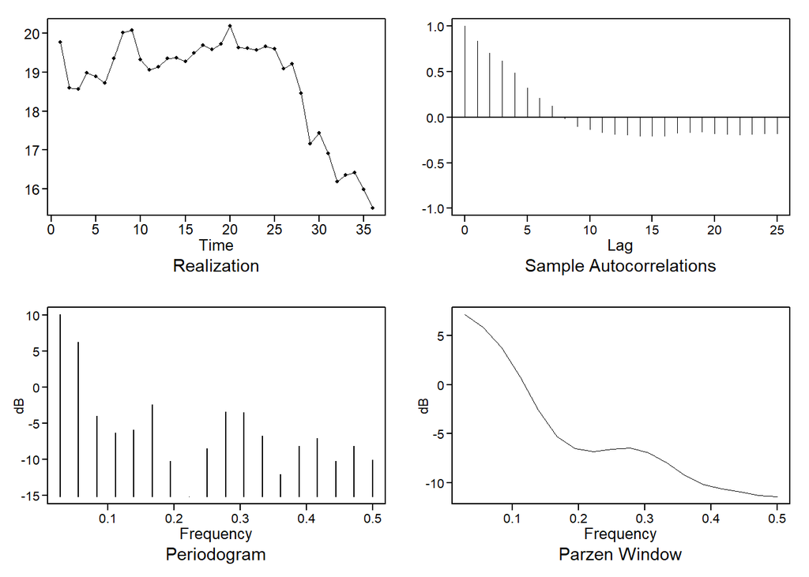

```
## $autplt
##  [1]  1.00000000  0.83880095  0.70631089  0.61828086  0.48624413  0.32441203
##  [7]  0.21013770  0.12202428 -0.01090714 -0.10204501 -0.13210805 -0.16824737
## [13] -0.18559263 -0.19393303 -0.20520626 -0.20569900 -0.20266985 -0.17415374
## [19] -0.16361462 -0.16183009 -0.17653322 -0.18337914 -0.19142185 -0.18622071
## [25] -0.18218041 -0.18130190
##
## $freq
##  [1] 0.02777778 0.05555556 0.08333333 0.11111111 0.13888889 0.16666667
##  [7] 0.19444444 0.22222222 0.25000000 0.27777778 0.30555556 0.33333333
## [13] 0.36111111 0.38888889 0.41666667 0.44444444 0.47222222 0.50000000
##
## $db
##  [1]  10.079212   6.266477  -3.950668  -6.258239  -5.870440  -2.343800
##  [7] -10.251454 -15.157110  -8.502239  -3.361715  -3.455042  -6.724634
## [13] -12.059686  -8.133352  -7.037388 -10.229570  -8.164175 -10.039273
##
## $dbz
##  [1]   7.1131615   5.8804371   3.7631517   0.7918253  -2.5980484  -5.2598690
##  [7]  -6.5043183  -6.7946397  -6.5835054  -6.4599467  -6.9074824  -7.9684787
## [13]  -9.2549099 -10.1869943 -10.6238683 -10.9203011 -11.2464417 -11.4096664
```

```r
#ARIMA Model Plotting
plotts.sample.wge(alldata$CO2)
```

```r
aic5.wge(alldata$CO2,p=0:10) #AIC shows an ARMA(2,1) is best fit
```

```
## ---------WORKING... PLEASE WAIT...
##
##
## Error in aic calculation at 2 0
## Error in aic calculation at 2 2
## Error in aic calculation at 3 0
## Error in aic calculation at 3 1
## Error in aic calculation at 3 2
## Error in aic calculation at 4 0
## Error in aic calculation at 6 0
## Error in aic calculation at 9 0
## Error in aic calculation at 10 0
## Five Smallest Values of  aic
```

```
##       p    q        aic
## 8     2    1  -1.504102
## 16    5    0  -1.500456
## 5     1    1  -1.494131
## 25    8    0  -1.488924
## 6     1    2  -1.486012
```

```r
aic5.wge(alldata$CO2, type="bic") #BIC shows an ARMA(1,1) is best fit
```

```
## ---------WORKING... PLEASE WAIT...
##
##
## Error in aic calculation at 2 0
## Error in aic calculation at 2 2
## Error in aic calculation at 3 0
## Error in aic calculation at 3 1
## Error in aic calculation at 3 2
## Error in aic calculation at 4 0
## Five Smallest Values of  bic
```

```
##       p    q        bic
## 5     1    1  -1.362171
## 4     1    0  -1.338871
## 8     2    1  -1.328156
## 6     1    2  -1.310066
## 16    5    0  -1.236537
```

```r
#fit the model -- ARMA(1.1)
est.arma.wge(alldata$CO2, p=1, q=1)
```

```
##
## Coefficients of Original polynomial:
## 0.9127
##
## Factor                 Roots                Abs Recip    System Freq
## 1-0.9127B              1.0957               0.9127       0.0000
##
##
```

```
## $phi
## [1] 0.9126689
##
## $theta
## [1] -0.5966692
##
## $res
##  [1] -0.49909206 -0.78710441  0.43933627  0.13005995 -0.14966137 -0.05816010
##  [7]  0.66433380  0.31869592 -0.01214983 -0.62741170  0.16036478  0.01690351
## [13]  0.23414638 -0.07117832  0.01404955  0.25965688  0.10713690 -0.09035276
## [19]  0.27683868  0.37431373 -0.63823601  0.43771078 -0.23248950  0.30665916
## [25] -0.16755441 -0.32174484  0.34843082 -0.92059330 -0.77733183  0.61270567
## [31] -1.00504715 -0.27975010  0.11502159 -0.22022850 -0.49650994 -0.42987896
##
## $avar
## [1] 0.1899873
##
## $aic
## [1] -1.494131
##
## $aicc
## [1] -0.4027335
##
## $bic
## [1] -1.362171
##
## $se.phi
## [1] 0.006514733
##
## $se.theta
## [1] 0.04548115
```

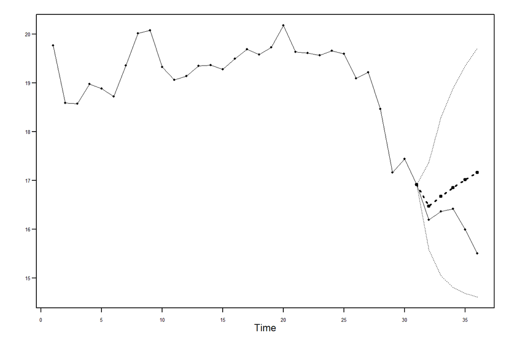

```r
m1 = fore.arma.wge(alldata$CO2,phi=0.9126689,theta = -0.5966692 , n.ahead = 5,lastn=TRUE,  plot=TRUE)
```

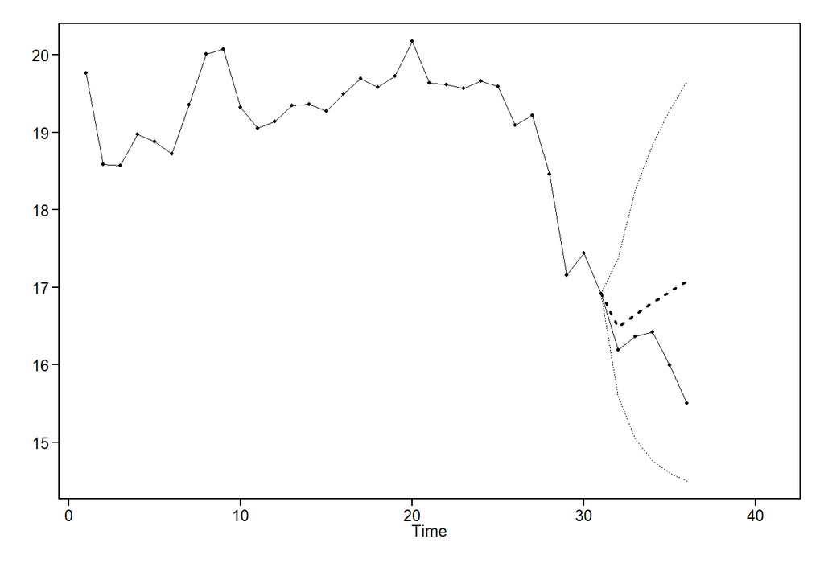

```r
#mean((alldata$CO2[53:57]-m1$f)^2)
#ASE =  0.8390832

# #Using the ARMA(1,1) to plot the 5 years ahead
# fore.arma.wge(co2_total$CO2,phi=0.9261945,theta = -0.5741199 , n.ahead = 5,lastn=FALSE,  plot=TRUE)
# #Using the ARMA(1,1) to plot the 20 years ahead
# fore.arma.wge(co2_total$CO2,phi=0.9261945,theta = -0.5741199 , n.ahead = 20,lastn=FALSE,  plot=TRUE)


#ASE's and Forecasts ================
#5 years out
n.ahead=5
CO2_f5 = fore.aruma.wge(x=alldata$CO2, phi=0.9261945, theta=-0.5741199, n.ahead=n.ahead, lastn=TRUE)
```

```r
#calculate ASE
StaticASE(series=alldata$CO2, forecast=CO2_f5$f, n.ahead=n.ahead)
```

```
## [1] "5 year ASE: 0.740201800887329"
```

```r
#"5 year ASE: 0.740201800887329"

#forecast
armafore5=fore.aruma.wge(x=alldata$CO2, phi=0.9261945, theta=-0.5741199, n.ahead=n.ahead, lastn=FALSE) #also used in ensemble
```

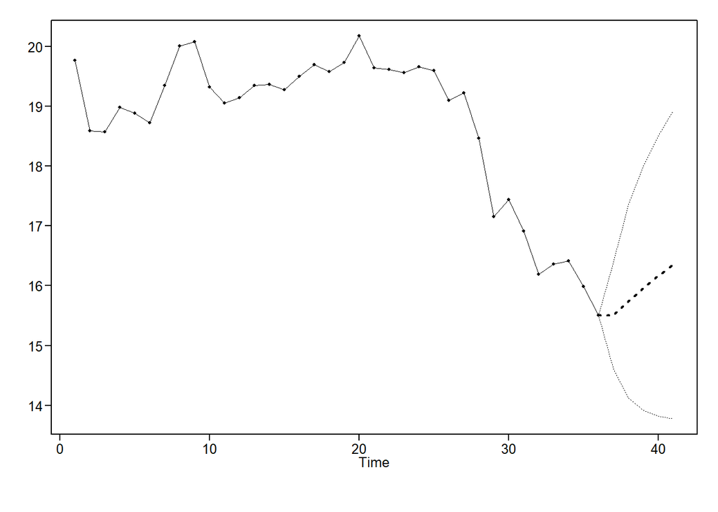

```r
#20 years out
n.ahead=20
CO2_f20 = fore.aruma.wge(x=alldata$CO2, phi=0.9261945, theta=-0.5741199, n.ahead=n.ahead, lastn=TRUE)
```

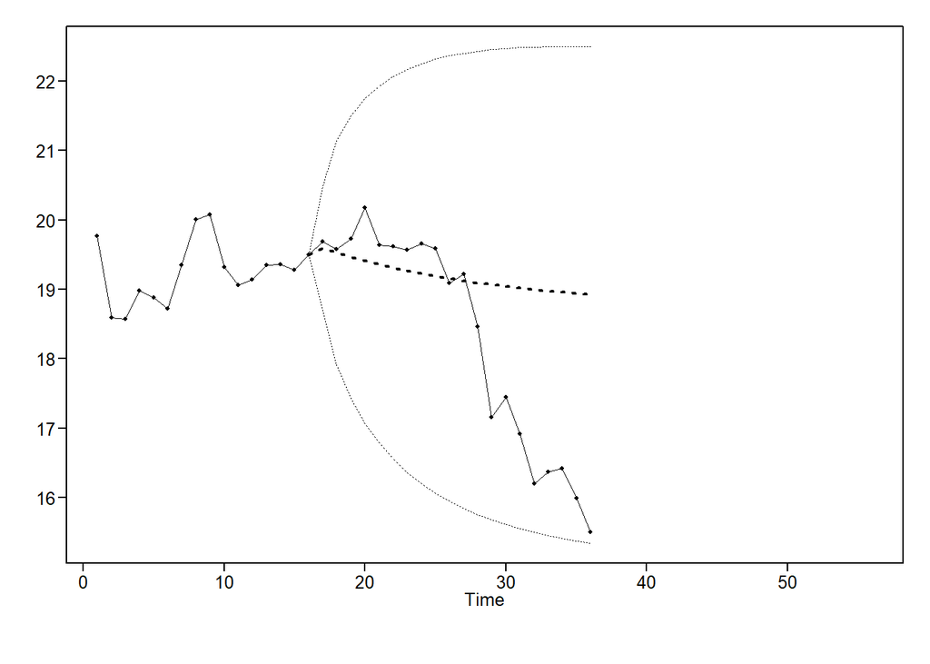

```r
#calculate ASE
StaticASE(series=alldata$CO2, forecast=CO2_f20$f, n.ahead=n.ahead)
```

```
## [1] "20 year ASE: 2.69083287859986"
```

```r
#"20 year ASE: 2.69083287859986"

#forecast
armafore20 = fore.aruma.wge(x=alldata$CO2, phi=0.9261945, theta=-0.5741199, n.ahead=n.ahead, lastn=FALSE) #also used in ensemble
```

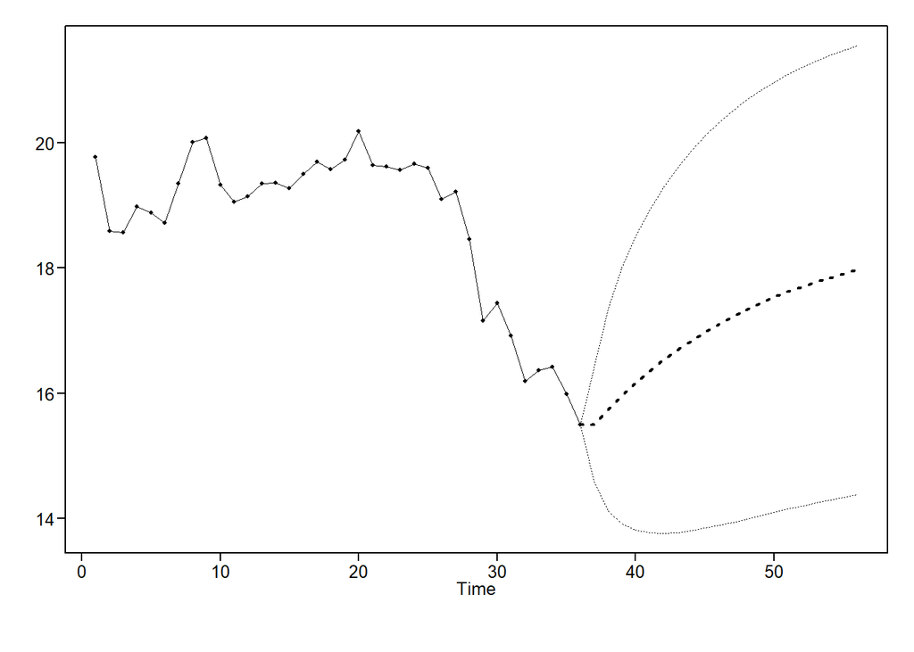

```r
#rolling window ASE
R_W_ASE(alldata$CO2, phis=0.9261945, thetas=-0.5741199, trainingSize=20, horizon=5)
```

```
## [1] "i: 1"
## [1] "ASE: 0.333109178598193"
## [1] "i: 2"
## [1] "ASE: 0.114582802874668"
## [1] "i: 3"
## [1] "ASE: 0.151560829507815"
## [1] "i: 4"
## [1] "ASE: 0.230838923872856"
## [1] "i: 5"
## [1] "ASE: 1.77376436640449"
## [1] "i: 6"
## [1] "ASE: 2.16427217089749"
## [1] "i: 7"
## [1] "ASE: 2.18739373579179"
## [1] "i: 8"
## [1] "ASE: 5.40244096206849"
## [1] "i: 9"
## [1] "ASE: 2.23994677879918"
## [1] "i: 10"
## [1] "ASE: 0.702377712228657"
## [1] "i: 11"
## [1] "ASE: 3.13251595398098"
## [1] "i: 12"
## [1] "ASE: 0.87289545529945"
```

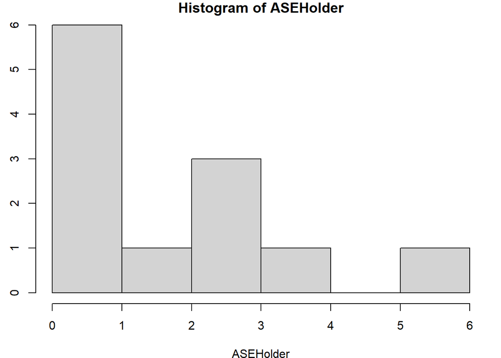

```
## [1] "The Summary Statistics for the Rolling Window ASE Are:"
##    Min. 1st Qu.  Median    Mean 3rd Qu.    Max.
##  0.1146  0.3075  1.3233  1.6088  2.2005  5.4024
## [1] "The Rolling Window ASE is:  1.60880823919367"
```

```
## [1] 1.608808
```

```r
#"The Rolling Window ASE is:  1.60880823919367"
```

# ARIMA Model #2:

An arima model will be fit to the data. Some assumptions for this model will be that the data is non-stationary and non-seasonal, and that the data is correlation based rather than signal-plus-noise based. This is reinforced by roots close to 1 in an over-fit factor table.

```r
#Look at the factor table
est.arma.wge(alldata$CO2, p=8)
```

```
##
## Coefficients of Original polynomial:
## 1.2775 -0.6902 0.8692 -0.6509 0.3260 -0.4407 0.5207 -0.2883
##
## Factor                 Roots                Abs Recip    System Freq
## 1-1.8468B+0.8688B^2    1.0628+-0.1464i      0.9321       0.0218
## 1+0.2629B+0.8438B^2   -0.1558+-1.0775i      0.9186       0.2729
## 1+1.3108B+0.7149B^2   -0.9168+-0.7472i      0.8455       0.3912
## 1-1.0044B+0.5500B^2    0.9130+-0.9922i      0.7417       0.1316
##
##
```

```
## $phi
## [1]  1.2774993 -0.6901662  0.8691964 -0.6509335  0.3259690 -0.4407207  0.5207319
## [8] -0.2882617
##
## $theta
## [1] 0
##
## $res
##  [1] -0.203235160 -0.664292481  0.049288950  0.037662541  0.281007061
##  [6]  0.130279251  0.489817590  0.286330040  0.467350517 -0.685875169
## [11] -0.314692808 -0.148168510  0.585408190  0.028142638 -0.064414539
## [16]  0.057340449  0.302566267  0.067721177  0.212871810  0.322177758
## [21] -0.527822396  0.333824868 -0.373151464  0.398290480 -0.123648831
## [26] -0.176949292 -0.001025944 -0.721354280 -0.781265776  0.298691306
## [31] -0.686268658 -0.093390241  0.077359682 -0.053607820 -0.387822295
## [36] -0.150457931
##
## $avar
## [1] 0.1368426
##
## $aic
## [1] -1.488924
##
## $aicc
## [1] -0.1889243
##
## $bic
## [1] -1.093045
##
## $se.phi
## [1] 0.03239629 0.08298850 0.08313045 0.10459260 0.10158911 0.08388010 0.07357154
## [8] 0.03346373
##
## $se.theta
## [1] 0
```

```r
#differencing a d=1 seasonal component
co2_diff = artrans.wge(alldata$CO2, phi.tr=c(1))
```

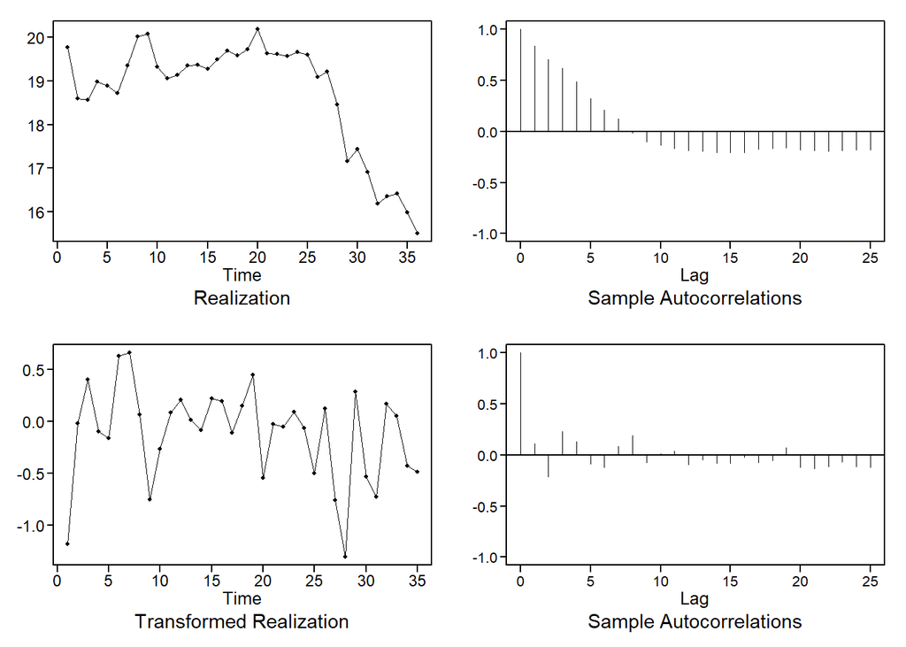

```r
#fit the differenced data
aic5.wge(co2_diff) #AR(1,1) recommended
```

```
## ---------WORKING... PLEASE WAIT...
##
##
## Five Smallest Values of  aic
```

```
##       p    q        aic
## 5     1    1  -1.619376
## 10    3    0  -1.615620
## 8     2    1  -1.602692
## 3     0    2  -1.582961
## 2     0    1  -1.576218
```

```r
co2_diff_est = est.arma.wge(co2_diff, 1, 1) #est AR(1,1) on differenced data
```

```
##
## Coefficients of Original polynomial:
## -0.4536
##
## Factor                 Roots                Abs Recip    System Freq
## 1+0.4536B             -2.2044               0.4536       0.5000
##
##
```

```r
co2_diff_est
```

```
## $phi
## [1] -0.4536403
##
## $theta
## [1] -0.8277382
##
## $res
##  [1] -0.833311735  0.314327655  0.313546556  0.006964211 -0.033077045
##  [6]  0.760805277  0.493066802  0.133782745 -0.656989222  0.112745712
## [11]  0.046133285  0.384354017 -0.033020761  0.126368326  0.253734669
## [16]  0.260995478 -0.061884980  0.325864385  0.426077288 -0.512952374
## [21]  0.332623105 -0.157985764  0.379791432 -0.160972500 -0.217618136
## [26]  0.255249730 -0.734120866 -0.862260826  0.584658767 -0.705278614
## [31] -0.200349035  0.184324477  0.155469674 -0.353623498 -0.211409097
##
## $avar
## [1] 0.1668259
##
## $aic
## [1] -1.619376
##
## $aicc
## [1] -0.5241381
##
## $bic
## [1] -1.486061
##
## $se.phi
## [1] 0.07909822
##
## $se.theta
## [1] 0.03703284
```

```r
#check residuals
ljung.wge(co2_diff_est$res, K=24) #p = 0.892, > 0.05
```

```
## Obs -0.1037706 -0.09214791 0.1604397 0.1285674 -0.09643078 -0.04277449 0.0251133 0.2118172 -0.1403455 0.05281456 0.03668299 -0.09175836 -0.01053985 -0.07910184 -0.03622592 -0.0348605 -0.02379577 -0.08379938 0.1277927 -0.1694039 -0.03728696 -0.1434699 0.007276599 -0.1287144
```

```
## $test
## [1] "Ljung-Box test"
##
## $K
## [1] 24
##
## $chi.square
## [1] 15.88242
##
## $df
## [1] 24
##
## $pval
## [1] 0.8922734
```

```r
ljung.wge(co2_diff_est$res, K=34) #p = 0.45, > 0.05
```

[output not shown]

```
## $test
## [1] "Ljung-Box test"
##
## $K
## [1] 34
##
## $chi.square
## [1] 34.37013
##
## $df
## [1] 34
##
## $pval
## [1] 0.4500216
```

```r
#residuals appear to be whitened
#second Ljung test length is 34 due to data length


#ASE's and Forecasts ======================
#5 years out
n.ahead=5
CO2_f = fore.aruma.wge(x=alldata$CO2, phi=c(-0.4536403), theta=c(-0.8277382), d=1, s=0, n.ahead=n.ahead, lastn=TRUE)
```

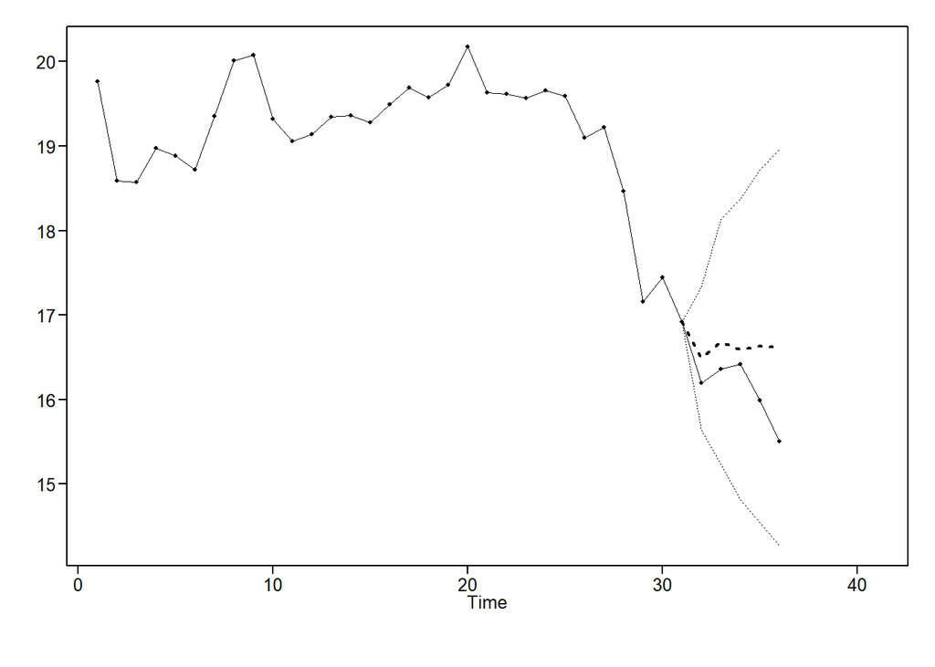

```r
#calculate ASE
StaticASE(series=alldata$CO2, forecast=CO2_f$f, n.ahead=n.ahead)
```

```
## [1] "5 year ASE: 0.374575891938278"
```

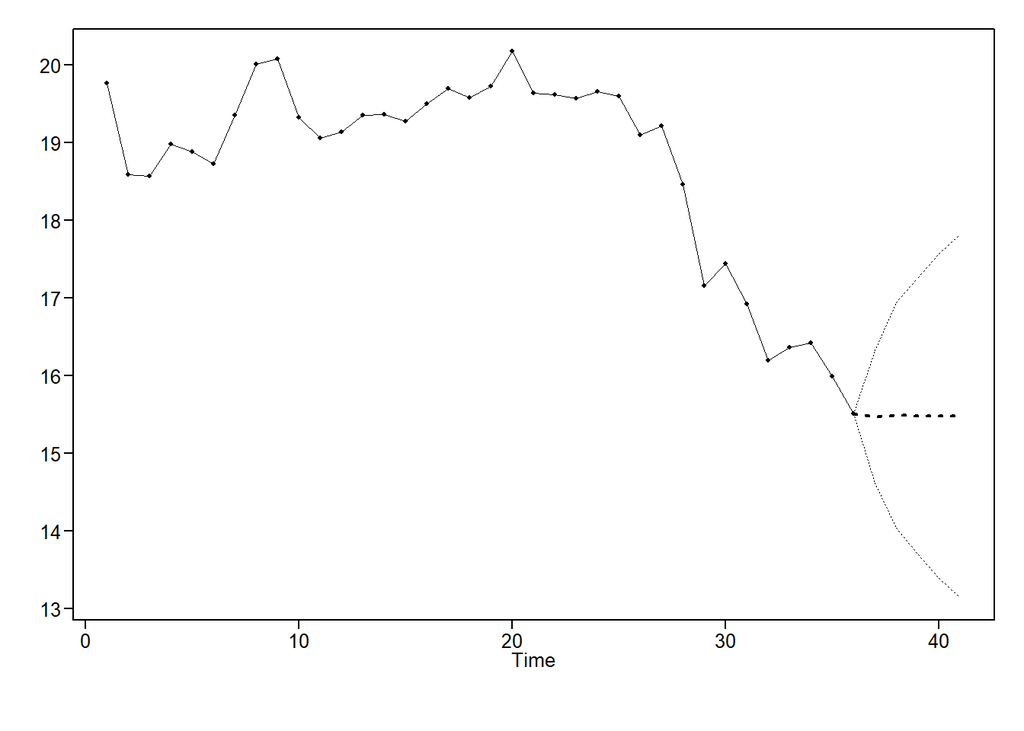

```
## $f
## [1] 15.46947 15.48432 15.47758 15.48064 15.47925
##
## $ll
## [1] 14.61543 14.03292 13.69866 13.39206 13.13503
##
## $ul
## [1] 16.32351 16.93572 17.25651 17.56922 17.82347
##
## $resid
##  [1]  0.00000000  0.00000000 -0.55255451  0.85397987 -0.61749126  0.30669042
##  [7]  0.30244858  0.69534799 -0.21077129 -0.54890687 -0.15383639  0.08967529
## [13]  0.17119445 -0.03369862 -0.05018877  0.22275954  0.10951660 -0.11361830
## [19]  0.19156784  0.36012149 -0.63547641  0.25692273 -0.27244385  0.29741457
## [25] -0.26990420 -0.30456940  0.15010442 -0.82420625 -0.96481192  0.49242601
## [31] -0.80605221 -0.29405309  0.08476871  0.06075760 -0.45234488 -0.30681184
##
## $wnv
## [1] 0.1898641
##
## $se
## [1] 0.4357339 0.7405099 0.9076145 1.0656018 1.1960305
##
## $psi
## [1] 1.374098 1.204392 1.281377 1.246454 1.262297
##
## $ptot
## [1] 2
##
## $phitot
## [1] 0.5463597 0.4536403
```

```r
#"5 year ASE: 0.374575891938278"

#forecast
fore.aruma.wge(x=alldata$CO2, phi=c(-0.4536403), theta=c(-0.8277382), d=1, s=0, n.ahead=n.ahead, lastn=FALSE)
```

```r
#20 years out
n.ahead=20
CO2_f = fore.aruma.wge(x=alldata$CO2, phi=c(-0.4536403), theta=c(-0.8277382), d=1, s=0, n.ahead=n.ahead, lastn=TRUE)
```

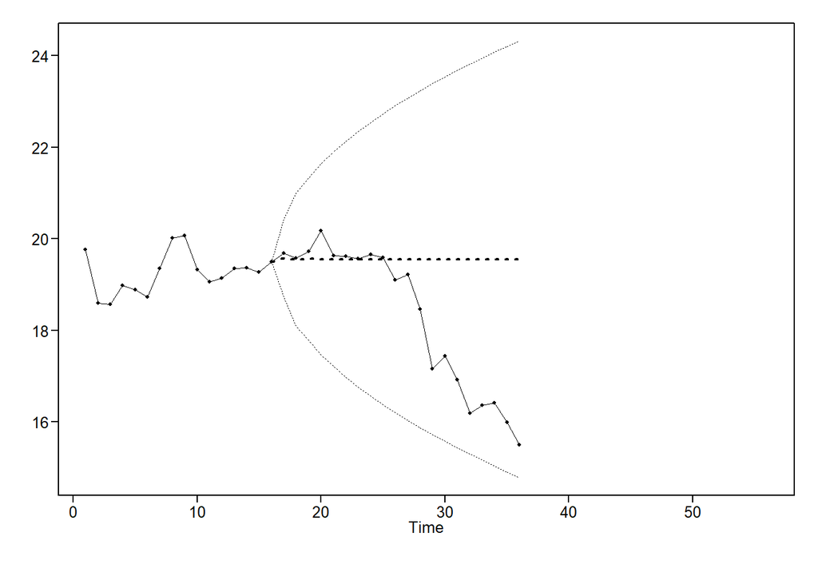

```r
#calculate ASE
StaticASE(series=alldata$CO2, forecast=CO2_f$f, n.ahead=n.ahead)
```

```
## [1] "20 year ASE: 3.97997954166426"
```

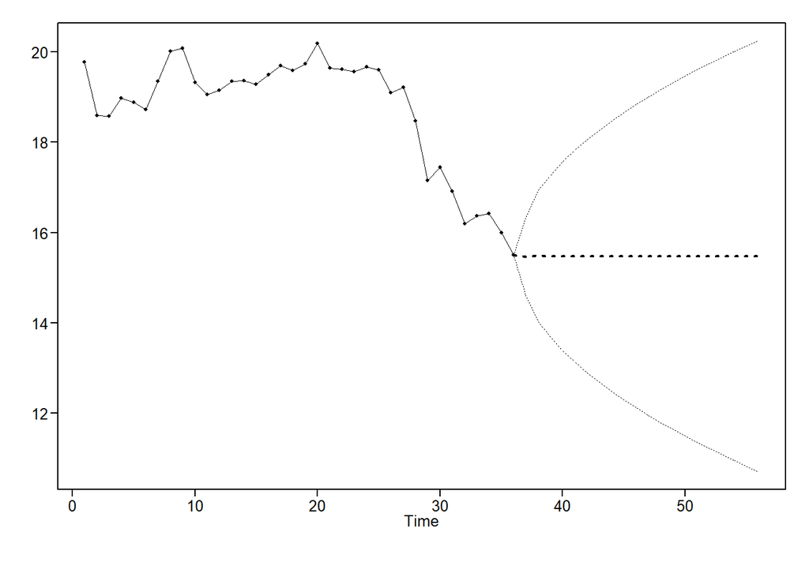

```
## $f
##  [1] 15.46947 15.48432 15.47758 15.48064 15.47925 15.47988 15.47959 15.47972
##  [9] 15.47967 15.47969 15.47968 15.47969 15.47968 15.47968 15.47968 15.47968
## [17] 15.47968 15.47968 15.47968 15.47968
##
## $ll
##  [1] 14.61543 14.03292 13.69866 13.39206 13.13503 12.89966 12.68557 12.48614
##  [9] 12.29945 12.12302 11.95545 11.79548 11.64218 11.49476 11.35262 11.21520
## [17] 11.08208 10.95287 10.82725 10.70494
##
## $ul
##  [1] 16.32351 16.93572 17.25651 17.56922 17.82347 18.06010 18.27362 18.47330
##  [9] 18.65988 18.83637 19.00391 19.16389 19.31719 19.46460 19.60675 19.74416
## [17] 19.87728 20.00649 20.13211 20.25443
##
## $resid
##  [1]  0.00000000  0.00000000 -0.55255451  0.85397987 -0.61749126  0.30669042
##  [7]  0.30244858  0.69534799 -0.21077129 -0.54890687 -0.15383639  0.08967529
## [13]  0.17119445 -0.03369862 -0.05018877  0.22275954  0.10951660 -0.11361830
## [19]  0.19156784  0.36012149 -0.63547641  0.25692273 -0.27244385  0.29741457
## [25] -0.26990420 -0.30456940  0.15010442 -0.82420625 -0.96481192  0.49242601
## [31] -0.80605221 -0.29405309  0.08476871  0.06075760 -0.45234488 -0.30681184
##
## $wnv
## [1] 0.1898641
##
## $se
##  [1] 0.4357339 0.7405099 0.9076145 1.0656018 1.1960305 1.3164410 1.4255209
##  [8] 1.5273371 1.6225600 1.7125898 1.7980771 1.8796980 1.9579116 2.0331220
## [15] 2.1056462 2.1757549 2.2436737 2.3095962 2.3736886 2.4360953
##
## $psi
##  [1] 1.374098 1.204392 1.281377 1.246454 1.262297 1.255110 1.258370 1.256891
##  [9] 1.257562 1.257257 1.257396 1.257333 1.257361 1.257348 1.257354 1.257352
## [17] 1.257353 1.257352 1.257353 1.257352
##
## $ptot
## [1] 2
##
## $phitot
## [1] 0.5463597 0.4536403
```

```r
#"20 year ASE: 3.97997954166426"

#forecast
fore.aruma.wge(x=alldata$CO2, phi=c(-0.4536403), theta=c(-0.8277382), d=1, s=0, n.ahead=n.ahead, lastn=FALSE)
```

```r
#rolling window ASE==============
R_W_ASE(alldata$CO2, trainingSize=20, horizon=5, s=0, d=1, thetas=c(-0.8277382), phis=c(-0.4536403))
```

```
## [1] "i: 1"
## [1] "ASE: 0.403288996758392"
## [1] "i: 2"
## [1] "ASE: 0.0513293331707895"
## [1] "i: 3"
## [1] "ASE: 0.161175679991314"
## [1] "i: 4"
## [1] "ASE: 0.239750410869345"
## [1] "i: 5"
## [1] "ASE: 1.91487938594071"
## [1] "i: 6"
## [1] "ASE: 2.08817207205032"
## [1] "i: 7"
## [1] "ASE: 2.25066691283304"
## [1] "i: 8"
## [1] "ASE: 4.68873000403971"
## [1] "i: 9"
## [1] "ASE: 2.21871707299521"
## [1] "i: 10"
## [1] "ASE: 0.342299483699318"
## [1] "i: 11"
## [1] "ASE: 1.68736270167623"
## [1] "i: 12"
## [1] "ASE: 0.371182401250541"
```

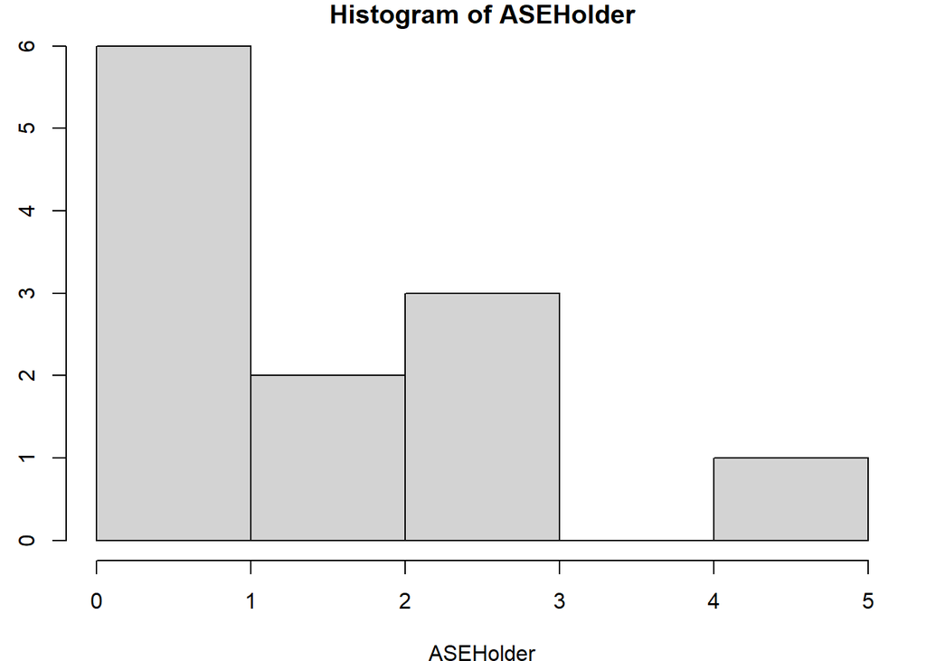

```
## [1] "The Summary Statistics for the Rolling Window ASE Are:"
##    Min. 1st Qu.  Median    Mean 3rd Qu.    Max.
## 0.05133 0.31666 1.04533 1.36813 2.12081 4.68873
## [1] "The Rolling Window ASE is:  1.36812953793958"
```

```
## [1] 1.36813
```

```r
#"The Summary Statistics for the Rolling Window ASE Are:"
#   Min. 1st Qu.  Median    Mean 3rd Qu.    Max.
#0.05133 0.31666 1.04533 1.36813 2.12081 4.68873
# "The Rolling Window ASE is:  1.36812953793958"
```